# Sipsey floodplain 4th corner analysis

Questions to answer:  
1.) Where are species found across the floodplain?  
a. Simple analysis of plots  
2.) What are the drivers that are leading to this distribution?  
a. Manyglm to test for significant drivers  
b. Multivarient SDM (part of the mvabund package)  
3.) What are the drivers of ecosystem functions in BLH forests (based on the tree species)? The functions I’m looking at are; nutrient uptake (Carbon, Nitrogen, Phosphorus), water storage, and wildlife food production.  
a. Pulled data from the Try trait database for the dominant trees in the forest.  
b. Ran fourth corner analysis  
See https://heather-grab.github.io/Entom-4940/rql.html for more information on each step  
#Step 1: Workspace orginization/data read in

[output not shown]

[output not shown]

#Step 2: Explore the data/manyglm model creation  
The goal here is to explore some potential models to see what covarients have a significant effect on tree species distribution.

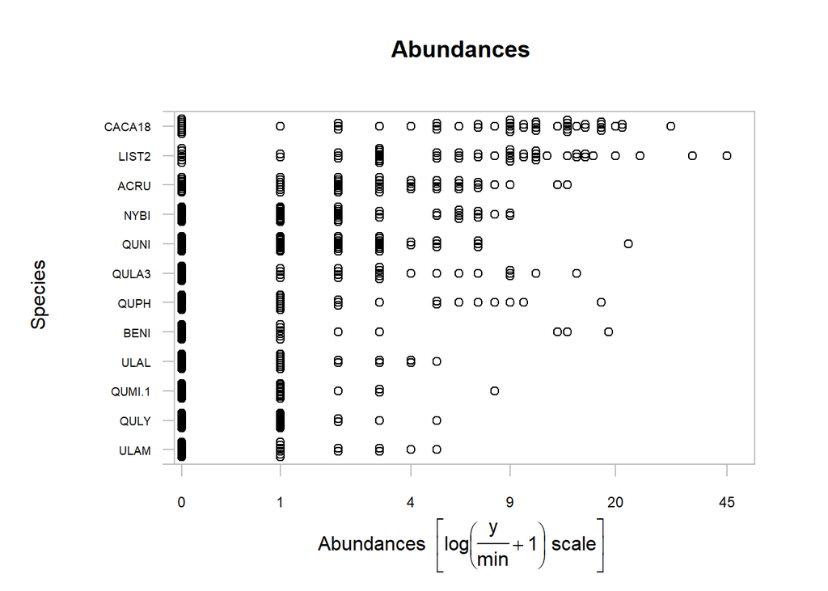

```r
#look at abundance across the floodplain
Tree_spp=mvabund(abd)
rownames(Tree_spp)<-c(0:49)
plot(Tree_spp)
plot(Tree_spp)
```

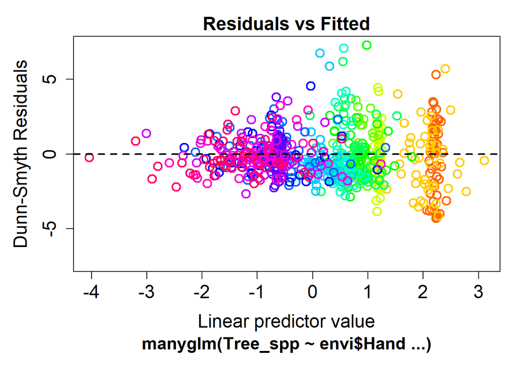

```r
#manyglm Plot to see if there is a pattern/cone
mod1 <- manyglm(Tree_spp ~ envi$Hand, family="poisson")
plot(mod1)
```

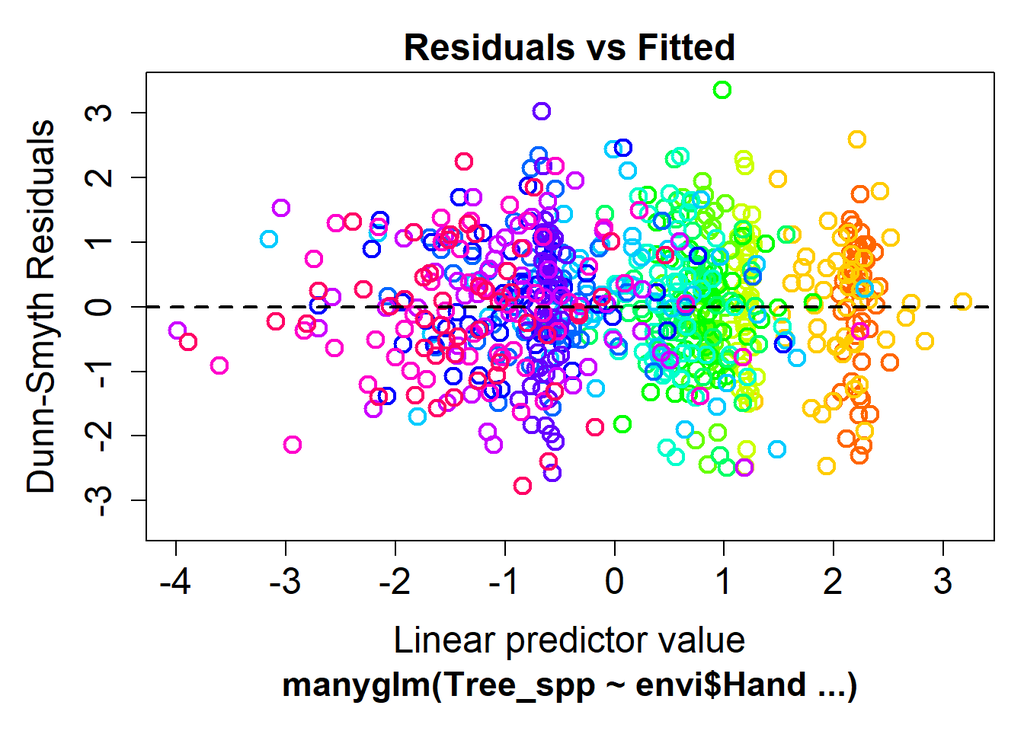

```r
mod2= manyglm(Tree_spp ~ envi$Hand, family="negative_binomial")
plot(mod2)
```

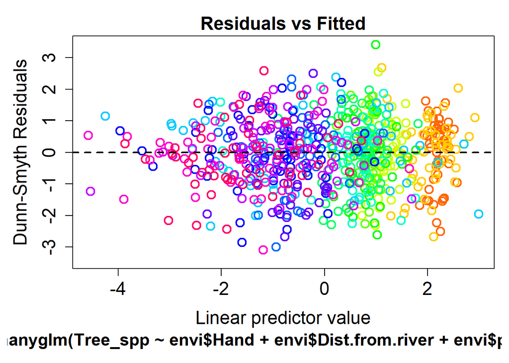

```r
mod3=manyglm(Tree_spp~envi$Hand+envi$`Dist.from.river`+envi$plotsd, family = "negative_binomial")
plot(mod3)
```

```r
#hypothesis testing with Anova
anova(mod3, nBoot=99)
anova(mod2, p.uni="adjusted", nBoot=99)
```

[output not shown]

#Step 3 multivarient SDM (https://cran.r-project.org/web/packages/mvabund/mvabund.pdf)\ The simplest form is a multivariate species distribution model (SDM) which predicts the abundance of each species based only on the environmental variables. The form of this model is essentially a negative binomial GLM with species as a fixed effect and a species by envi interaction.

```r
sdm_fit=traitglm(abd,envi)
```

```
## No traits matrix entered, so will fit SDMs with different env response for each spp
```

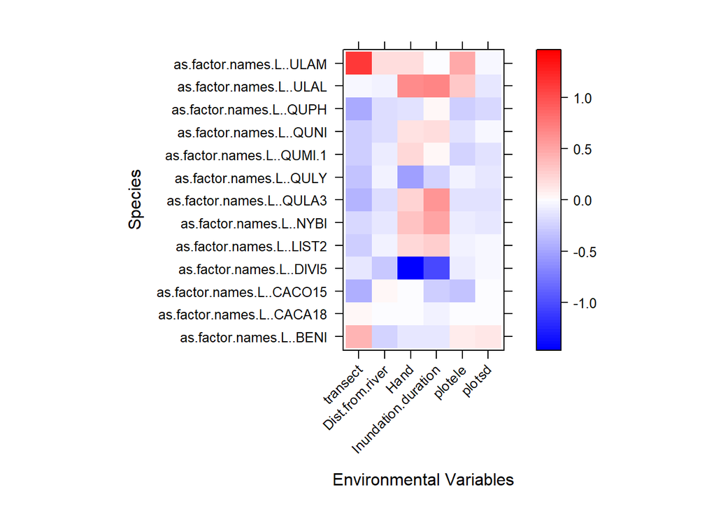

```r
#plot
a        = max( abs(sdm_fit$fourth.corner) )
colort   = colorRampPalette(c("blue","white","red"))
plot.spp = levelplot(t(as.matrix(sdm_fit$fourth.corner)), xlab="Environmental Variables",
                     ylab="Species", col.regions=colort(100), at=seq(-a, a, length=100),
                     scales = list( x= list(rot = 45)))
print(plot.spp)
```

```r
#Run ANOVa on the model
anova.traitglm(sdm_fit)
```

```
## No traits matrix entered, so will fit SDMs with different env response for each spp
## Resampling begins for test 1.
##  Resampling run 0 finished. Time elapsed: 0.01 minutes...
## Time elapsed: 0 hr 0 min 41 sec
```

```
## Analysis of Deviance Table
##
## Model  1: traitglm(L = abd, R = envi, get.fourth = FALSE)
## Model  2: traitglm(L = abd, R = envi)
##
## Multivariate test:
##                           Res.Df Df.diff Dev Pr(>Dev)
## Main effects only            674
## env:trait (fourth corner)    596      78 201     0.01 **
## ---
## Signif. codes:  0 '***' 0.001 '**' 0.01 '*' 0.05 '.' 0.1 ' ' 1
## Arguments: P-value calculated using 99 iterations via PIT-trap block resampling.
```

The heat map resulting from this data is a good visual representation of each environmental variables effect on specific tree species

#Step 4: Forth corner analysis  
The forth corner analysis functions similarly to the multivarient SDM but looks at the environmental varibles effect on tree  
traits. The trait data was downloaded from the TRY plant trait database and more data will soon be added from the NEON database.

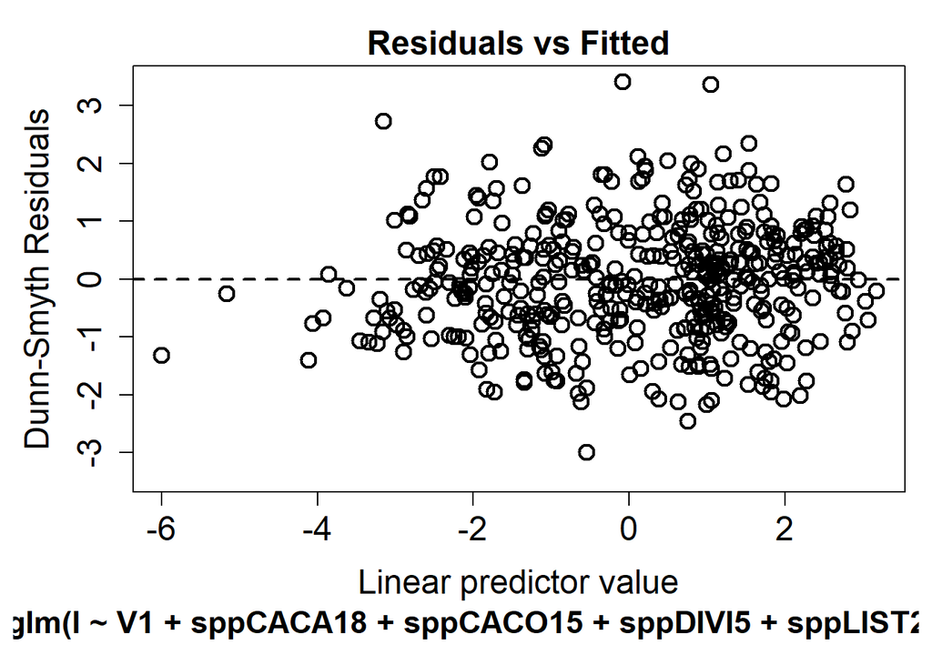

```r
#forth corner analysis
traits=traits
abd4th=abd %>%
  mutate(QUMI=QUMI.1) %>%
  select(ACRU,CACA18,CACO15,DIVI5,LIST2,QULA3,QUNI,QUMI,ULAM)
fit=traitglm(abd4th,envi,traits)
#print fourth corner terms
#plot residuals
plot(fit)
```

```r
#Check anova
anova(fit, nBoot = 10)
```

```
## Resampling begins for test 1.
##  Resampling run 0 finished. Time elapsed: 0.00 minutes...
## Time elapsed: 0 hr 0 min 0 sec
```

```
## Analysis of Deviance Table
##
## Model  1: traitglm(L = abd4th, R = envi, Q = traits, get.fourth = FALSE)
## Model  2: traitglm(L = abd4th, R = envi, Q = traits)
##
## Multivariate test:
##                           Res.Df Df.diff Dev Pr(>Dev)
## Main effects only            429
## env:trait (fourth corner)    387      42 102    0.091 .
## ---
## Signif. codes:  0 '***' 0.001 '**' 0.01 '*' 0.05 '.' 0.1 ' ' 1
## Arguments: P-value calculated using 10 iterations via PIT-trap block resampling.
```

```r
#summary can give you the effects of indivudual traits by environment interactions
#this is slow use nBoot=10 for test but 1000 for final analysis
summary(fit, nBoot=10)
```

```
##
## Test statistics:
##                                                   wald value Pr(>wald)
## (Intercept)                                            0.833    0.9091
## sppCACA18                                              4.724    0.0909 .
## sppCACO15                                              7.115    0.0909 .
## sppDIVI5                                               6.611    0.0909 .
## sppLIST2                                               3.880    0.0909 .
## sppQULA3                                               3.448    0.0909 .
## sppQUMI                                                6.573    0.0909 .
## sppQUNI                                                1.748    0.3636
## sppULAM                                                6.364    0.0909 .
## transect                                               1.052    0.4545
## Dist.from.river                                        1.838    0.2727
## Hand                                                   1.136    0.2727
## Inundation.duration                                    0.842    0.3636
## plotele                                                0.341    0.7273
## plotsd                                                 0.524    0.5455
## transect.squ                                           2.448    0.0909 .
## Dist.from.river.squ                                    1.420    0.4545
## Hand.squ                                               1.766    0.2727
## Inundation.duration.squ                                1.666    0.3636
## plotele.squ                                            1.960    0.1818
## plotsd.squ                                             0.776    0.7273
## transect.waterlog.tolerance                            2.527    0.0909 .
## transect.soilpH                                        0.055    1.0000
## transect.NP.Ratio.g.cm3                                3.390    0.0909 .
## transect.LMA.petiol.undefined.mm2.mg.1                 3.270    0.0909 .
## transect.LMA.petiol.excluded.mm2.mg.1                  5.088    0.0909 .
## transect.leaf.N.mg.g                                   2.891    0.1818
## transect.leaf.P.mg.g                                   3.778    0.0909 .
## Dist.from.river.waterlog.tolerance                     0.293    0.8182
## Dist.from.river.soilpH                                 1.152    0.3636
## Dist.from.river.NP.Ratio.g.cm3                         0.561    0.2727
## Dist.from.river.LMA.petiol.undefined.mm2.mg.1          0.160    0.8182
## Dist.from.river.LMA.petiol.excluded.mm2.mg.1           1.796    0.0909 .
## Dist.from.river.leaf.N.mg.g                            0.161    0.8182
## Dist.from.river.leaf.P.mg.g                            0.971    0.3636
## Hand.waterlog.tolerance                                0.270    0.9091
## Hand.soilpH                                            0.144    1.0000
```

[output cut: 16 more lines]

```
## plotele.LMA.petiol.excluded.mm2.mg.1                   2.660    0.0909 .
## plotele.leaf.N.mg.g                                    1.573    0.3636
## plotele.leaf.P.mg.g                                    2.346    0.0909 .
## plotsd.waterlog.tolerance                              1.118    0.2727
## plotsd.soilpH                                          1.031    0.4545
## plotsd.NP.Ratio.g.cm3                                  1.189    0.1818
## plotsd.LMA.petiol.undefined.mm2.mg.1                   0.508    0.4545
## plotsd.LMA.petiol.excluded.mm2.mg.1                    1.476    0.0909 .
## plotsd.leaf.N.mg.g                                     0.210    0.7273
## plotsd.leaf.P.mg.g                                     0.267    0.7273
## ---
## Signif. codes:  0 '***' 0.001 '**' 0.01 '*' 0.05 '.' 0.1 ' ' 1
##
## Test statistic:  19.69, p-value: 0.0909
## Arguments: P-value calculated using 10 resampling iterations via pit.trap resampling.
```

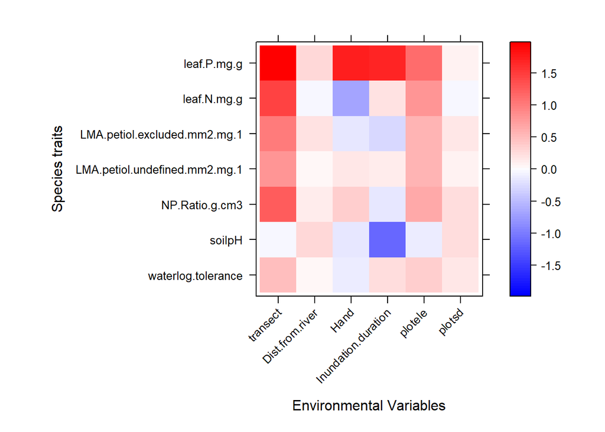

```r
#create heatmap
a        = max( abs(fit$fourth.corner) )
colort   = colorRampPalette(c("blue","white","red"))
plot.4th = levelplot(t(as.matrix(fit$fourth.corner)), xlab="Environmental Variables",
                     ylab="Species traits", col.regions=colort(100), at=seq(-a, a, length=100),
                     scales = list( x= list(rot = 45)))
print(plot.4th)
```

```r
#ANOVA
anova.traitglm(fit)
```

```
## Resampling begins for test 1.
##  Resampling run 0 finished. Time elapsed: 0.00 minutes...
## Time elapsed: 0 hr 0 min 12 sec
```

```
## Analysis of Deviance Table
##
## Model  1: traitglm(L = abd4th, R = envi, Q = traits, get.fourth = FALSE)
## Model  2: traitglm(L = abd4th, R = envi, Q = traits)
##
## Multivariate test:
##                           Res.Df Df.diff Dev Pr(>Dev)
## Main effects only            429
## env:trait (fourth corner)    387      42 102     0.01 **
## ---
## Signif. codes:  0 '***' 0.001 '**' 0.01 '*' 0.05 '.' 0.1 ' ' 1
## Arguments: P-value calculated using 99 iterations via PIT-trap block resampling.
```

The relationships seen in the heat map appear promising. Next steps for me are to:  
• Check NEON site for additional data/data we were missing from the Try database.  
• Find papers that have paired the physiological traits to a quantifiable function.

Note: As I work through the data analysis I’ll update this document